# 4.2 Check yourself (short version)

Module M-227-04: Programming for Data Analytics

NumPy - numerical Python (lesson 4.1)

## The tools of lesson 4.1

Every question that follows is answered by one of these:

`np.zeros` · `np.arange` · `np.random.randint` · `np.genfromtxt` · a boolean mask · `.copy()` · `axis=` · `@` · `np.linalg.solve` · `np.save`

and then: *in your own words - shape, dtype, reshape*, *what will be created?*, *how do you get ... from a 3×4 table?*, *what will be printed?*

In your own words:

# What is `dtype`?

# the type of the elements - the same for the whole array

`int64`, `float64`, `bool`, `uint8` (0 … 255), text. One array = one dtype: a single decimal makes everything float, a single string makes everything text. `astype()` converts.

`arr` is this 3×4 array. **What will be printed?**

## `print(arr.max(axis=1))`

|  | col 0 | col 1 | col 2 | col 3 |
| --- | --- | --- | --- | --- |
| row 0 | 1 | 2 | 3 | 4 |
| row 1 | 5 | 6 | 7 | 8 |
| row 2 | 9 | 10 | 11 | 12 |

# [ 4 8 12]

The largest value of each row - here always the last column.

|  | col 0 | col 1 | col 2 | col 3 |
| --- | --- | --- | --- | --- |
| row 0 | 1 | 2 | 3 | 4 |
| row 1 | 5 | 6 | 7 | 8 |
| row 2 | 9 | 10 | 11 | 12 |

What will be printed?

```
print(np.array([1, 2.5, 3]).dtype)
```

# float64

One decimal is enough - the whole array becomes float: `[1. 2.5 3.]`.

`arr` is this 3×4 array. **What will be printed?**

## `print(arr.shape[0])`

|  | col 0 | col 1 | col 2 | col 3 |
| --- | --- | --- | --- | --- |
| row 0 | 1 | 2 | 3 | 4 |
| row 1 | 5 | 6 | 7 | 8 |
| row 2 | 9 | 10 | 11 | 12 |

# 3

`shape` is `(3, 4)`; element 0 of it is the number of rows. (For iris: `iris_data.shape[0]` = 150 flowers.)

|  | col 0 | col 1 | col 2 | col 3 |
| --- | --- | --- | --- | --- |
| row 0 | 1 | 2 | 3 | 4 |
| row 1 | 5 | 6 | 7 | 8 |
| row 2 | 9 | 10 | 11 | 12 |

`arr` is a 3×4 array: **row first, then column**, counting from 0.  
How do you get ...

# ... the first element?

|  | col 0 | col 1 | col 2 | col 3 |
| --- | --- | --- | --- | --- |
| row 0 | 1 | 2 | 3 | 4 |
| row 1 | 5 | 6 | 7 | 8 |
| row 2 | 9 | 10 | 11 | 12 |

# arr[0, 0]

→ `1`

Row 0, column 0 - one index per dimension, separated by a comma.

|  | col 0 | col 1 | col 2 | col 3 |
| --- | --- | --- | --- | --- |
| row 0 | 1 | 2 | 3 | 4 |
| row 1 | 5 | 6 | 7 | 8 |
| row 2 | 9 | 10 | 11 | 12 |

What will be created?

```
arr = np.zeros(1, 3)
```

# TypeError

Without the inner brackets the second argument is taken as the dtype - the shape must be a tuple: `np.zeros((1, 3))`.

What will be printed?

```
print(np.sqrt(np.array([1, 4, 9])))
```

# [1. 2. 3.]

A universal function works on every element at once and returns floats. `math.sqrt` from week 3 works on one number only - `math.sqrt(arr)` gives a TypeError.

`arr` is this 3×4 array. **What will be printed?**

## `print(arr[:, 0:2])`

|  | col 0 | col 1 | col 2 | col 3 |
| --- | --- | --- | --- | --- |
| row 0 | 1 | 2 | 3 | 4 |
| row 1 | 5 | 6 | 7 | 8 |
| row 2 | 9 | 10 | 11 | 12 |

# [[1 2] [5 6] [9 10]]

All rows, columns 0 and 1 (`0:2` stops before 2).

|  | col 0 | col 1 | col 2 | col 3 |
| --- | --- | --- | --- | --- |
| row 0 | 1 | 2 | 3 | 4 |
| row 1 | 5 | 6 | 7 | 8 |
| row 2 | 9 | 10 | 11 | 12 |

What will be created?

```
arr1d = np.zeros(3)
```

# [0. 0. 0.] - shape (3,)

One number → a 1D array (a vector) of 3 zeros. The dot after each 0 means the values are floats.

What will be created?

```
cube = np.zeros((2, 3, 4))
```

# a 3D array - shape (2, 3, 4), 24 zeros

Three numbers in the shape → three dimensions: 2 "layers", each with 3 rows and 4 columns (think: 2 tables of 3×4, or 2 images 3×4 pixels).

What will be printed?

```
m = np.array([[1, 2],
              [3, 4]])
print(m * m)
print(m @ m)
```

# [[1 4] [9 16]] and [[7 10] [15 22]]

`*` squares every element; `@` is the matrix product (row × column: 1·1 + 2·3 = 7, ...).

Which tool would you choose?

# Test data: a 5×5 table of random whole numbers from 0 to 9

# np.random.randint(0, 10, size=(5, 5))

The upper limit is not included; `np.random.seed(...)` makes it repeatable.

`arr1` and `arr2` are two 2×2 arrays. **What will be printed?**

## `print(arr1 * arr2)`

`arr1`

| 1 | 2 |
| --- | --- |
| 3 | 4 |

`arr2`

| 10 | 20 |
| --- | --- |
| 30 | 40 |

# `print(arr1 * arr2)`

`*` multiplies element by element (Hadamard product) - NOT the matrix product; that is `@`.

`arr1`

| 1 | 2 |
| --- | --- |
| 3 | 4 |

`arr2`

| 10 | 20 |
| --- | --- |
| 30 | 40 |

`result`

| 10 | 40 |
| --- | --- |
| 90 | 160 |

What will be printed?

```
print(np.array(["3.5", "4"]).astype(float))
```

# [3.5 4. ]

`astype(float)` converts text that looks like numbers into real numbers - the way to repair a column read as strings.

What will be printed?

```
a = np.arange(5)
s = a[1:3]
s[:] = 0
print(a)
```

# [0 0 0 3 4]

`s` is a view of `a` - writing into the slice changes the original.

`arr` is a 3×4 array: **row first, then column**, counting from 0.  
How do you get ...

# ... the element in row 1, column 2?

|  | col 0 | col 1 | col 2 | col 3 |
| --- | --- | --- | --- | --- |
| row 0 | 1 | 2 | 3 | 4 |
| row 1 | 5 | 6 | 7 | 8 |
| row 2 | 9 | 10 | 11 | 12 |

# arr[1, 2]

→ `7`

Second row, third column - remember, counting starts from 0.

|  | col 0 | col 1 | col 2 | col 3 |
| --- | --- | --- | --- | --- |
| row 0 | 1 | 2 | 3 | 4 |
| row 1 | 5 | 6 | 7 | 8 |
| row 2 | 9 | 10 | 11 | 12 |

`arr` is this 3×4 array. **What will be printed?**

## `print(arr[1:3, 1:3])`

|  | col 0 | col 1 | col 2 | col 3 |
| --- | --- | --- | --- | --- |
| row 0 | 1 | 2 | 3 | 4 |
| row 1 | 5 | 6 | 7 | 8 |
| row 2 | 9 | 10 | 11 | 12 |

# [[6 7] [10 11]]

Rows 1-2 and columns 1-2 - the middle block. Changing it would change `arr` too (a slice is a view).

|  | col 0 | col 1 | col 2 | col 3 |
| --- | --- | --- | --- | --- |
| row 0 | 1 | 2 | 3 | 4 |
| row 1 | 5 | 6 | 7 | 8 |
| row 2 | 9 | 10 | 11 | 12 |

What will be printed?

```
x = np.array([1.5, np.nan, 3.0])
print(np.isnan(x), np.isnan(x).sum())
```

# [False True False] 1

`np.isnan` finds the missing values; the sum of the mask counts them. `x.mean()` would be nan - use `np.nanmean(x)`.

`arr1` and `arr2` are two 2×2 arrays. **What will be printed?**

## `print(arr1 + arr2)`

`arr1`

| 1 | 2 |
| --- | --- |
| 3 | 4 |

`arr2`

| 10 | 20 |
| --- | --- |
| 30 | 40 |

# `print(arr1 + arr2)`

Element-wise: the first with the first, the second with the second ... Same shape → same shape back.

`arr1`

| 1 | 2 |
| --- | --- |
| 3 | 4 |

`arr2`

| 10 | 20 |
| --- | --- |
| 30 | 40 |

`result`

| 11 | 22 |
| --- | --- |
| 33 | 44 |

`arr` is this 3×4 array. **What will be printed?**

## `print(arr[:, 0] > 2)`

|  | col 0 | col 1 | col 2 | col 3 |
| --- | --- | --- | --- | --- |
| row 0 | 1 | 2 | 3 | 4 |
| row 1 | 5 | 6 | 7 | 8 |
| row 2 | 9 | 10 | 11 | 12 |

# [False True True]

Column 0 is `[1 5 9]`; comparing gives one True/False per row. Highlighted: where it is True. (Like `iris_data[:, 0] > 7`.)

|  | col 0 | col 1 | col 2 | col 3 |
| --- | --- | --- | --- | --- |
| row 0 | 1 | 2 | 3 | 4 |
| row 1 | 5 | 6 | 7 | 8 |
| row 2 | 9 | 10 | 11 | 12 |

`arr` is a 3×4 array: **row first, then column**, counting from 0.  
How do you get ...

# ... the last column?

|  | col 0 | col 1 | col 2 | col 3 |
| --- | --- | --- | --- | --- |
| row 0 | 1 | 2 | 3 | 4 |
| row 1 | 5 | 6 | 7 | 8 |
| row 2 | 9 | 10 | 11 | 12 |

# arr[:, -1]

→ `[4 8 12]`

All rows (`:`), column −1. A column comes back as a 1D array.

|  | col 0 | col 1 | col 2 | col 3 |
| --- | --- | --- | --- | --- |
| row 0 | 1 | 2 | 3 | 4 |
| row 1 | 5 | 6 | 7 | 8 |
| row 2 | 9 | 10 | 11 | 12 |

`arr` is this 3×4 array. **What will be printed?**

## `print(arr.mean(axis=0))`

|  | col 0 | col 1 | col 2 | col 3 |
| --- | --- | --- | --- | --- |
| row 0 | 1 | 2 | 3 | 4 |
| row 1 | 5 | 6 | 7 | 8 |
| row 2 | 9 | 10 | 11 | 12 |

# [5. 6. 7. 8.]

`axis=0` walks down the rows → one mean per column: (1+5+9)/3 = 5, … The result has 4 values - the rows disappeared.

|  | col 0 | col 1 | col 2 | col 3 |
| --- | --- | --- | --- | --- |
| row 0 | 1 | 2 | 3 | 4 |
| row 1 | 5 | 6 | 7 | 8 |
| row 2 | 9 | 10 | 11 | 12 |

In your own words:

# What is broadcasting?

# stretching the smaller array to the shape of the bigger one

When two arrays of different shapes meet in an operation, NumPy repeats the smaller one along the missing dimension - a number for every element, a row for every row - so no loop is needed. Shapes are compared from the right; a dimension of size 1 (or missing) is stretched, anything else is an error.

`arr * 4` - the number is stretched to (3, 3); `iris - iris.mean(axis=0)` - the row of 4 means is repeated for all 150 rows

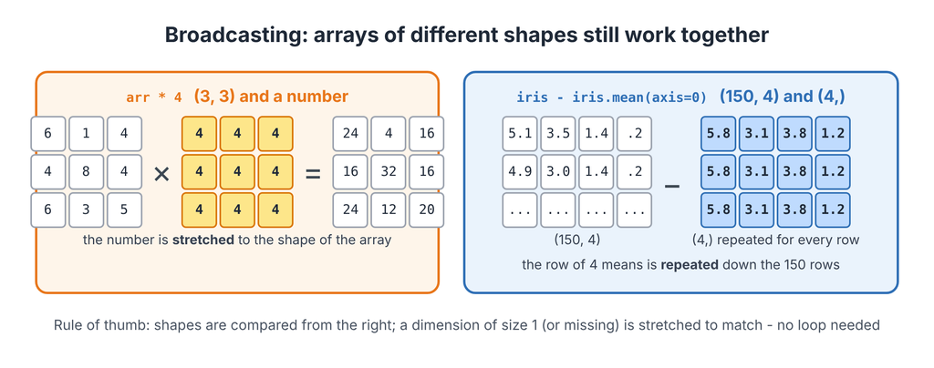

`arr` is this 3×4 array. **What will be printed?**

## `print((arr > 6).sum())`

|  | col 0 | col 1 | col 2 | col 3 |
| --- | --- | --- | --- | --- |
| row 0 | 1 | 2 | 3 | 4 |
| row 1 | 5 | 6 | 7 | 8 |
| row 2 | 9 | 10 | 11 | 12 |

# 6

True counts as 1 - the sum of a mask is the number of elements that satisfy the condition.

|  | col 0 | col 1 | col 2 | col 3 |
| --- | --- | --- | --- | --- |
| row 0 | 1 | 2 | 3 | 4 |
| row 1 | 5 | 6 | 7 | 8 |
| row 2 | 9 | 10 | 11 | 12 |

What will be printed?

```
a = np.zeros((2, 3))
print(a.shape, a.ndim, a.size)
```

# (2, 3) 2 6

2 rows × 3 columns: 2 dimensions, 6 elements.

What will be printed?

```
print(np.array([1, "two", 3]).dtype)
```

# <U21 (text)

One string makes EVERYTHING text: `['1' 'two' '3']` - the numbers are now strings too. This is the trap with CSV files: keep text columns out of a numeric array.

Which tool would you choose?

# Change a piece of an array without changing the original

# .copy()

A slice is a view onto the same data - copy it first.

Which tool would you choose?

# Load the numeric columns of a CSV file into an array

# np.genfromtxt('file.csv', delimiter=',', skip_header=1, usecols=(...))

Skip the header and leave the text columns out - one array has one dtype.

`arr` is this 3×4 array. **What will be printed?**

## `print(arr.mean(axis=1))`

|  | col 0 | col 1 | col 2 | col 3 |
| --- | --- | --- | --- | --- |
| row 0 | 1 | 2 | 3 | 4 |
| row 1 | 5 | 6 | 7 | 8 |
| row 2 | 9 | 10 | 11 | 12 |

# [ 2.5 6.5 10.5]

`axis=1` walks across the columns → one mean per row: (1+2+3+4)/4 = 2.5, … 3 values - the columns disappeared.

|  | col 0 | col 1 | col 2 | col 3 |
| --- | --- | --- | --- | --- |
| row 0 | 1 | 2 | 3 | 4 |
| row 1 | 5 | 6 | 7 | 8 |
| row 2 | 9 | 10 | 11 | 12 |

`arr` is a 3×4 array: **row first, then column**, counting from 0.  
How do you get ...

# ... the last element?

|  | col 0 | col 1 | col 2 | col 3 |
| --- | --- | --- | --- | --- |
| row 0 | 1 | 2 | 3 | 4 |
| row 1 | 5 | 6 | 7 | 8 |
| row 2 | 9 | 10 | 11 | 12 |

# arr[-1, -1]

→ `12`

Negative indices count from the end, as for lists (also `arr[2, 3]`).

|  | col 0 | col 1 | col 2 | col 3 |
| --- | --- | --- | --- | --- |
| row 0 | 1 | 2 | 3 | 4 |
| row 1 | 5 | 6 | 7 | 8 |
| row 2 | 9 | 10 | 11 | 12 |

`arr1` and `arr2` are two 2×2 arrays. **What will be printed?**

## `print(arr1 + arr2[0])`

`arr1`

| 1 | 2 |
| --- | --- |
| 3 | 4 |

`arr2`

| 10 | 20 |
| --- | --- |
| 30 | 40 |

# `print(arr1 + arr2[0])`

Broadcasting: `arr2[0]` is the row `[10 20]`; it is repeated for every row of `arr1`.

`arr1`

| 1 | 2 |
| --- | --- |
| 3 | 4 |

`arr2`

| 10 | 20 |
| --- | --- |
| 30 | 40 |

`result`

| 11 | 22 |
| --- | --- |
| 13 | 24 |

`arr` is this 3×4 array. **What will be printed?**

## `print(arr.argmax())`

|  | col 0 | col 1 | col 2 | col 3 |
| --- | --- | --- | --- | --- |
| row 0 | 1 | 2 | 3 | 4 |
| row 1 | 5 | 6 | 7 | 8 |
| row 2 | 9 | 10 | 11 | 12 |

# 11

The *position* of the largest value, counted row by row from 0 - the 12th element. `arr.argmax(axis=0)` would give `[2 2 2 2]`: the row of the maximum in each column.

|  | col 0 | col 1 | col 2 | col 3 |
| --- | --- | --- | --- | --- |
| row 0 | 1 | 2 | 3 | 4 |
| row 1 | 5 | 6 | 7 | 8 |
| row 2 | 9 | 10 | 11 | 12 |

`arr` is this 3×4 array. **What will be printed?**

## `print(arr[::-1])`

|  | col 0 | col 1 | col 2 | col 3 |
| --- | --- | --- | --- | --- |
| row 0 | 1 | 2 | 3 | 4 |
| row 1 | 5 | 6 | 7 | 8 |
| row 2 | 9 | 10 | 11 | 12 |

# [[9 10 11 12] [5 6 7 8] [1 2 3 4]]

A step of −1 walks backwards - the rows in reverse order (upside down, as for an image).

|  | col 0 | col 1 | col 2 | col 3 |
| --- | --- | --- | --- | --- |
| row 0 | 1 | 2 | 3 | 4 |
| row 1 | 5 | 6 | 7 | 8 |
| row 2 | 9 | 10 | 11 | 12 |

In your own words:

# What does `reshape` do?

# re-arranges the same elements into a new shape

The data stay in the same order (row by row); only the description changes. The product of the new shape must equal the number of elements: 12 → (3, 4), (2, 6), (2, 3, 2) - but not (5, 3).

In your own words:

# What is `shape`?

# the size of the array along each dimension - a tuple

`(3, 4)` = 3 rows and 4 columns; `(150, 4)` = 150 flowers × 4 measurements; `(559, 375, 3)` = an image. The number of numbers in the tuple is `ndim`.

Which tool would you choose?

# Multiply two matrices (rows by columns, not element by element)

# A @ B

`*` is element-wise; `@` (or `np.matmul`) is the matrix product.

`arr` is this 3×4 array. **What will be printed?**

## `print(arr[arr[:, 0] > 2])`

|  | col 0 | col 1 | col 2 | col 3 |
| --- | --- | --- | --- | --- |
| row 0 | 1 | 2 | 3 | 4 |
| row 1 | 5 | 6 | 7 | 8 |
| row 2 | 9 | 10 | 11 | 12 |

# [[5 6 7 8] [9 10 11 12]]

The mask `[False True True]` selects rows 1 and 2 - boolean indexing keeps the rows where the mask is True.

|  | col 0 | col 1 | col 2 | col 3 |
| --- | --- | --- | --- | --- |
| row 0 | 1 | 2 | 3 | 4 |
| row 1 | 5 | 6 | 7 | 8 |
| row 2 | 9 | 10 | 11 | 12 |

What will be created?

```
arr2d = np.zeros((3, 1))
```

# [[0.] [0.] [0.]] - shape (3, 1)

3 rows, 1 column - a column vector. Same 3 zeros as above, a different shape.

`arr` is this 3×4 array. **What will be printed?**

## `print(arr[-3:])`

|  | col 0 | col 1 | col 2 | col 3 |
| --- | --- | --- | --- | --- |
| row 0 | 1 | 2 | 3 | 4 |
| row 1 | 5 | 6 | 7 | 8 |
| row 2 | 9 | 10 | 11 | 12 |

# [[1 2 3 4] [5 6 7 8] [9 10 11 12]]

The last 3 rows - and the table has only 3, so it is the whole table. (`iris_data[-3:]` gives the last 3 flowers of 150.)

|  | col 0 | col 1 | col 2 | col 3 |
| --- | --- | --- | --- | --- |
| row 0 | 1 | 2 | 3 | 4 |
| row 1 | 5 | 6 | 7 | 8 |
| row 2 | 9 | 10 | 11 | 12 |